# hw_dplyr_p1p2

Sihyuan Han

# The flights data frame from the nycflights13 package

1. Load and review the data

```r
library(tidyverse)
library(nycflights13)
data("flights")
# What are the variables?
names(flights)
```

```
##  [1] "year"           "month"          "day"            "dep_time"
##  [5] "sched_dep_time" "dep_delay"      "arr_time"       "sched_arr_time"
##  [9] "arr_delay"      "carrier"        "flight"         "tailnum"
## [13] "origin"         "dest"           "air_time"       "distance"
## [17] "hour"           "minute"         "time_hour"
```

```r
# How many observations (rows) are there?
nrow(flights)
```

```
## [1] 336776
```

```r
# Look at the first three rows
head(flights, n = 3)
```

```
## # A tibble: 3 x 19
##    year month   day dep_time sched_dep_time dep_delay arr_time sched_arr_time
##   <int> <int> <int>    <int>          <int>     <dbl>    <int>          <int>
## 1  2013     1     1      517            515         2      830            819
## 2  2013     1     1      533            529         4      850            830
## 3  2013     1     1      542            540         2      923            850
## # … with 11 more variables: arr_delay <dbl>, carrier <chr>, flight <int>,
## #   tailnum <chr>, origin <chr>, dest <chr>, air_time <dbl>, distance <dbl>,
## #   hour <dbl>, minute <dbl>, time_hour <dttm>
```

2. Worst Plane to Fly

```r
# Which planes (tailnum) have the three worst (highest) average departure delay record?
flights%>%
  filter(!is.na(dep_delay))%>%
  slice_max(dep_delay, n=3)%>%
  select(tailnum,dep_delay)
```

```
## # A tibble: 3 x 2
##   tailnum dep_delay
##   <chr>       <dbl>
## 1 N384HA       1301
## 2 N504MQ       1137
## 3 N517MQ       1126
```

```r
# How many flights did it make?
flights%>%
  filter(!is.na(dep_delay))%>%
  slice_max(dep_delay, n=3)%>%
  select(tailnum,flight,dep_delay)
```

```
## # A tibble: 3 x 3
##   tailnum flight dep_delay
##   <chr>    <int>     <dbl>
## 1 N384HA      51      1301
## 2 N504MQ    3535      1137
## 3 N517MQ    3695      1126
```

```r
# Now only look tailnums where each flew more than 12 flights and find the three tailnums with the highest average departure delay
flights%>%
  filter(flight > 12)%>%
  filter(!is.na(dep_delay))%>%
  slice_max(dep_delay, n=3)%>%
  select(tailnum)
```

```
## # A tibble: 3 x 1
##   tailnum
##   <chr>
## 1 N384HA
## 2 N504MQ
## 3 N517MQ
```

3. Best Time of Day to Fly

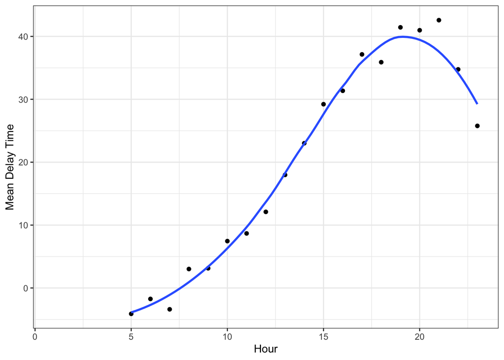

```r
flights%>%
  group_by(hour)%>%
  summarize(mean_delay = mean(arr_delay, na.rm = TRUE) +
              mean(dep_delay, na.rm = TRUE))%>%
  ggplot(aes(x = as.numeric(hour), y = mean_delay)) +
  geom_point() +
  geom_smooth(se = FALSE) +
  theme_bw() +
  xlab("Hour") +
  ylab("Mean Delay Time")
```

4. Worst Flight Numbers for each Destination

```r
flights%>%
  select(dest,arr_delay,tailnum)%>%
  group_by(dest)%>%
  filter(arr_delay > 0)%>%
  mutate(total_arr_delay = sum(arr_delay, na.rm = TRUE),
         pro_arr_delay = arr_delay/total_arr_delay, na.rm = TRUE)
```

```
## # A tibble: 133,004 x 6
## # Groups:   dest [103]
##    dest  arr_delay tailnum total_arr_delay pro_arr_delay na.rm
##    <chr>     <dbl> <chr>             <dbl>         <dbl> <lgl>
##  1 IAH          11 N14228            99391     0.000111  TRUE
##  2 IAH          20 N24211            99391     0.000201  TRUE
##  3 MIA          33 N619AA           140424     0.000235  TRUE
##  4 ORD          12 N39463           283046     0.0000424 TRUE
##  5 FLL          19 N516JB           202605     0.0000938 TRUE
##  6 ORD           8 N3ALAA           283046     0.0000283 TRUE
##  7 LAX           7 N29129           203226     0.0000344 TRUE
##  8 DFW          31 N3DUAA           110009     0.000282  TRUE
##  9 ATL          12 N542MQ           300299     0.0000400 TRUE
## 10 DTW          16 N730MQ           138258     0.000116  TRUE
## # … with 132,994 more rows
```

5. Destinations with Multiple Carriers from NYC Area

```r
flights %>%
  group_by(dest)%>%
  summarise(num_carrier = n_distinct(carrier))%>%
  filter(num_carrier >= 2)%>%
  arrange(desc(num_carrier))%>%
  slice(25:30)
```

```
## # A tibble: 6 x 2
##   dest  num_carrier
##   <chr>       <int>
## 1 SFO             5
## 2 BUF             4
## 3 BWI             4
## 4 CHS             4
## 5 CVG             4
## 6 DFW             4
```

6. Effect of the Delay in the Flight before Yours

```r
# Using lag() and cor()...
flights%>%
  filter(!is.na(dep_delay))%>%
  mutate(pre_dep_delay = lag(dep_delay,default = 0)) ->
  flights_dep_delay

cor(flights_dep_delay$dep_delay, flights_dep_delay$pre_dep_delay)
```

```
## [1] 0.3250215
```

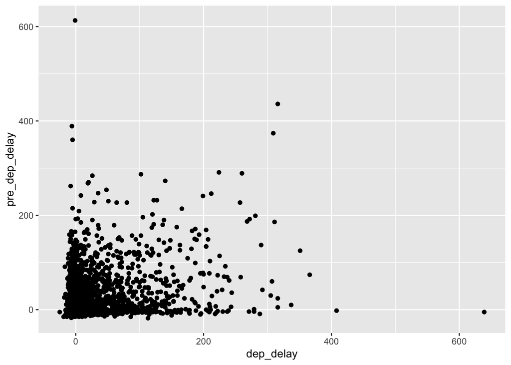

```r
# EXTRA CREDIT...
flights_dep_delay%>%
  slice_sample(n = 5000)%>%
  ggplot(aes(x = dep_delay,y = pre_dep_delay)) +
  geom_point()
```

## Star Wars Characters

1. Load the data into R and load any necessary packages

```r
library(tidyverse)
data("starwars")
```

2. Use appropriate R code to determine which individuals have missing gender. Make sure to only print out their names and heights, arranged in ascending order of height

```r
starwars%>%
  filter(is.na(gender) == TRUE)%>%
  select(name, height)%>%
  arrange(height)
```

```
## # A tibble: 4 x 2
##   name           height
##   <chr>           <int>
## 1 Sly Moore         178
## 2 Ric Olié          183
## 3 Quarsh Panaka     183
## 4 Captain Phasma     NA
```

3. It seems all individuals in part 2 are droids. Change their gender to “droid” and save to the dataframe

```r
starwars$gender[is.na(starwars$gender)] <- "droid"
starwars%>%
  select(name, height, gender)%>%
  filter(gender == "droid")
```

```
## # A tibble: 4 x 3
##   name           height gender
##   <chr>           <int> <chr>
## 1 Ric Olié          183 droid
## 2 Quarsh Panaka     183 droid
## 3 Sly Moore         178 droid
## 4 Captain Phasma     NA droid
```

4. BMI

```r
# Calculate the BMI and add it to the starwars data frame
starwars%>%
  mutate(bmi = mass / (height/100)^2)%>%
# Sanity check: The median BMI should be in the 20-30 range
  mutate(Sanity_check = case_when(
    bmi>=20 & bmi<=30 ~ "checked"
  ))
```

```
## # A tibble: 87 x 16
##    name  height  mass hair_color skin_color eye_color birth_year sex   gender
##    <chr>  <int> <dbl> <chr>      <chr>      <chr>          <dbl> <chr> <chr>
##  1 Luke…    172    77 blond      fair       blue            19   male  mascu…
##  2 C-3PO    167    75 <NA>       gold       yellow         112   none  mascu…
##  3 R2-D2     96    32 <NA>       white, bl… red             33   none  mascu…
##  4 Dart…    202   136 none       white      yellow          41.9 male  mascu…
##  5 Leia…    150    49 brown      light      brown           19   fema… femin…
##  6 Owen…    178   120 brown, gr… light      blue            52   male  mascu…
##  7 Beru…    165    75 brown      light      blue            47   fema… femin…
##  8 R5-D4     97    32 <NA>       white, red red             NA   none  mascu…
##  9 Bigg…    183    84 black      light      brown           24   male  mascu…
## 10 Obi-…    182    77 auburn, w… fair       blue-gray       57   male  mascu…
## # … with 77 more rows, and 7 more variables: homeworld <chr>, species <chr>,
## #   films <list>, vehicles <list>, starships <list>, bmi <dbl>,
## #   Sanity_check <chr>
```

5. Calculate the median and mean height for each gender as well as the number of individuals

```r
starwars%>%
  group_by(gender)%>%
  summarize(mean_height = mean(height, na.rm = TRUE),
            median_height = median(height, na.rm = TRUE),
            number_of_individuals = length(gender))
```

```
## # A tibble: 3 x 4
##   gender    mean_height median_height number_of_individuals
## * <chr>           <dbl>         <dbl>                 <int>
## 1 droid            181.          183                      4
## 2 feminine         165.          166.                    17
## 3 masculine        177.          183                     66
```

6. Make boxplots of gender vs BMI. Include only masculine, feminine, and droids. Use the black and white theme

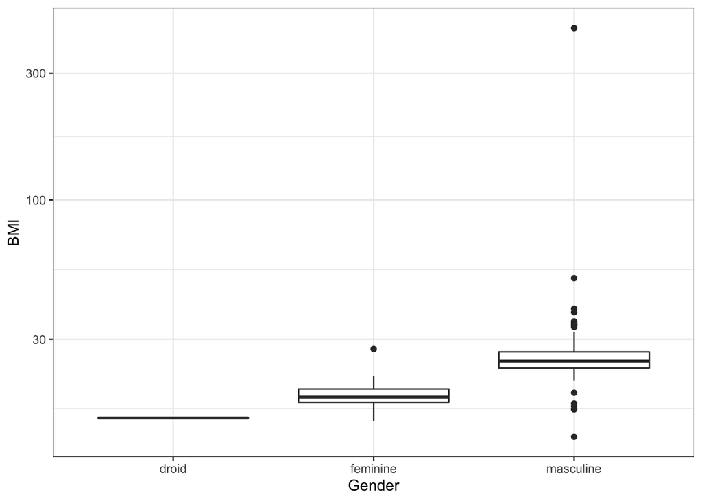

```r
starwars%>%
  mutate(bmi = mass / (height/100)^2 )%>%
  filter(!is.na(gender))%>%
ggplot(aes(x = gender,y = bmi)) +
geom_boxplot() +
  scale_y_log10() +
  theme_bw() +
  xlab("Gender") +
  ylab("BMI")
```

7. Make scatterplots of height vs mass, faceting by gender

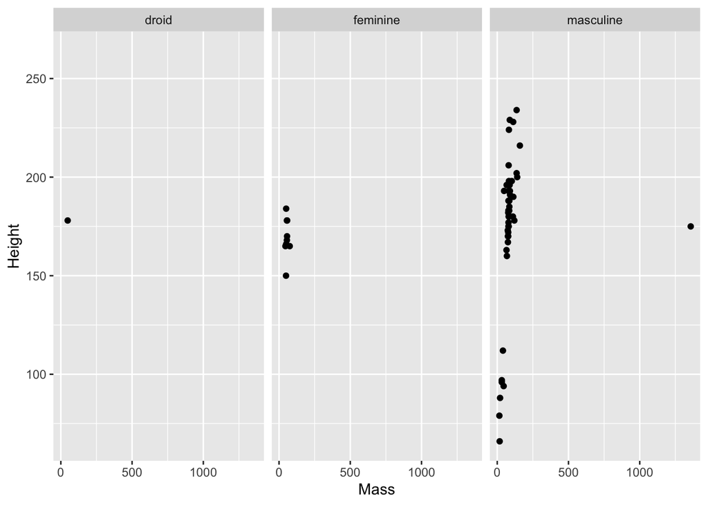

```r
starwars%>%
  ggplot(aes(x = mass,y = height)) +
  geom_point() +
  facet_wrap( ~ gender) +
  xlab("Mass") +
  ylab("Height")
```

8. Reproduce the following plot

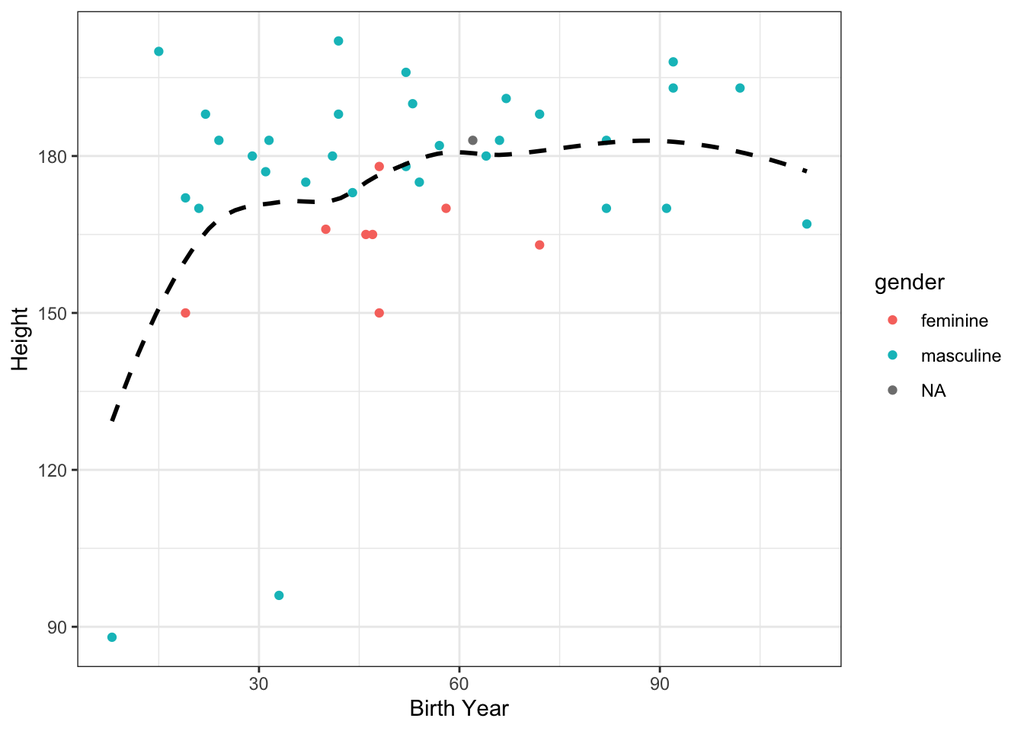

```r
starwars%>%
  filter(birth_year>0 & birth_year<120)%>%
  mutate(gender = na_if(gender, "droid"))%>%
  ggplot(aes(x = birth_year,y = height, col = gender)) +
  geom_point() +
  geom_smooth(se = FALSE, color = "black", linetype = "dashed") +
  theme_bw() +
  xlab("Birth Year") +
  ylab("Height")
```

### The Palmer Penguins Package

```r
library(tidyverse)
library(palmerpenguins)
data("penguins")
head(penguins)
```

```
## # A tibble: 6 x 8
##   species island bill_length_mm bill_depth_mm flipper_length_… body_mass_g sex
##   <fct>   <fct>           <dbl>         <dbl>            <int>       <int> <fct>
## 1 Adelie  Torge…           39.1          18.7              181        3750 male
## 2 Adelie  Torge…           39.5          17.4              186        3800 fema…
## 3 Adelie  Torge…           40.3          18                195        3250 fema…
## 4 Adelie  Torge…           NA            NA                 NA          NA <NA>
## 5 Adelie  Torge…           36.7          19.3              193        3450 fema…
## 6 Adelie  Torge…           39.3          20.6              190        3650 male
## # … with 1 more variable: year <int>
```

2. Bill Ratio

```r
penguins%>%
  mutate(fb_ratio=flipper_length_mm/bill_length_mm)
```

```
## # A tibble: 344 x 9
##    species island bill_length_mm bill_depth_mm flipper_length_… body_mass_g
##    <fct>   <fct>           <dbl>         <dbl>            <int>       <int>
##  1 Adelie  Torge…           39.1          18.7              181        3750
##  2 Adelie  Torge…           39.5          17.4              186        3800
##  3 Adelie  Torge…           40.3          18                195        3250
##  4 Adelie  Torge…           NA            NA                 NA          NA
##  5 Adelie  Torge…           36.7          19.3              193        3450
##  6 Adelie  Torge…           39.3          20.6              190        3650
##  7 Adelie  Torge…           38.9          17.8              181        3625
##  8 Adelie  Torge…           39.2          19.6              195        4675
##  9 Adelie  Torge…           34.1          18.1              193        3475
## 10 Adelie  Torge…           42            20.2              190        4250
## # … with 334 more rows, and 3 more variables: sex <fct>, year <int>,
## #   fb_ratio <dbl>
```

3. Using the data frame from 2., eliminate the penguins with an fb_ration of NA and show the highest four penguins of each sex with only the character variables and fb_ratio

```r
penguins%>%
  mutate(fb_ratio=flipper_length_mm/bill_length_mm)%>%
  filter(!is.na(fb_ratio))%>%
  select(sex,fb_ratio)%>%
  group_by(sex)%>%
  slice_max(fb_ratio, n=4)
```

```
## # A tibble: 12 x 2
## # Groups:   sex [3]
##    sex    fb_ratio
##    <fct>     <dbl>
##  1 female     5.86
##  2 female     5.67
##  3 female     5.66
##  4 female     5.49
##  5 male       5.72
##  6 male       5.50
##  7 male       5.34
##  8 male       5.31
##  9 <NA>       5.66
## 10 <NA>       4.92
## 11 <NA>       4.88
## 12 <NA>       4.85
```

4. For each species and sex, calculate the median of the numeric variables

```r
penguins%>%
  group_by(species,sex)%>%
  summarize(across(where(is.numeric),
                  ~ median(.x, na.rm = TRUE)))
```

```
## # A tibble: 8 x 7
## # Groups:   species [3]
##   species  sex   bill_length_mm bill_depth_mm flipper_length_… body_mass_g  year
##   <fct>    <fct>          <dbl>         <dbl>            <dbl>       <dbl> <dbl>
## 1 Adelie   fema…           37            17.6             188        3400   2008
## 2 Adelie   male            40.6          18.9             193        4000   2008
## 3 Adelie   <NA>            37.8          18.1             186        3475   2007
## 4 Chinstr… fema…           46.3          17.6             192        3550   2008
## 5 Chinstr… male            51.0          19.3             200.       3950   2008
## 6 Gentoo   fema…           45.5          14.2             212        4700   2008
## 7 Gentoo   male            49.5          15.7             221        5500   2008
## 8 Gentoo   <NA>            45.4          14.4             216        4688.  2009
```

4.1 Then use an appropriate plot to show median bill length vs bill depth by species and sex

```r
penguins%>%
  group_by(species,bill_depth_mm,sex)%>%
  summarize(median_bill_length = median(bill_length_mm,na.rm = TRUE)) ->
  sum_penguins
```

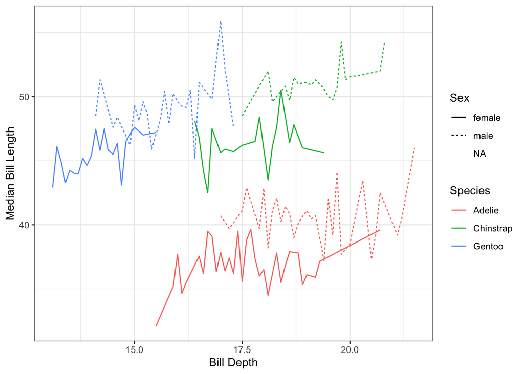

```r
ggplot(data = sum_penguins,
       mapping = aes(x = bill_depth_mm, y = median_bill_length,
                     col = species, linetype = sex))+
  geom_line()+
  theme_bw()+
  xlab("Bill Depth")+
  ylab("Median Bill Length")+
  scale_color_discrete(name = "Species")+
  scale_linetype_discrete(name = "Sex")
```

4.2 Interpret the plot in one sentence: Female penguin tends to have shorter bill Length than male penguin; Chinstrap and Gentoo species tend to have longer bill length than Adelie.

5. How many rows have no missing values?

```r
penguins%>%
  filter(across(everything(),
                ~ !is.na(.x)))%>%
  nrow()
```

```
## [1] 333
```

6. How many unique values are there for each of the columns that end in "_mm" for each sex

```r
penguins%>%
  group_by(sex)%>%
  summarize(across(contains("_mm"),
                   ~ length(unique(.x))))
```

```
## # A tibble: 3 x 4
##   sex    bill_length_mm bill_depth_mm flipper_length_mm
## * <fct>           <int>         <int>             <int>
## 1 female             97            56                41
## 2 male              110            58                49
## 3 <NA>                8            10                 9
```